# Persona Memory Ranker: cleaning, exploration, and evaluation

DSCI 310 project

# 1 Question and data provenance

The analysis asks whether a small reranker can select useful conversation memories for a new question under a fixed context-token budget. The unit of evaluation is a question. Candidate memories from one persona are correlated, so training, validation, and benchmark partitions must keep personas separate. Five-fold cross-validation also groups by persona; smoke runs with fewer personas use fewer folds and are development checks rather than full benchmark results.

The source training and validation files share personas, so their original split labels do not provide persona isolation. The ingestion stage preserves the benchmark, excludes its personas from development, and repartitions the pooled development personas deterministically into training and validation groups. The download manifest documents the exact repair; `original_split`, when present, retains source provenance. Counts below refer to these evaluation partitions.

The relevant-memory annotations are **synthetic and incomplete**. An annotated memory is a positive example; an unannotated candidate is not a verified negative. Retrieval recall and ranking metrics therefore measure recovery of these labels, not all useful context or the truthfulness of a final assistant answer. Exact alignment can fail, and the alignment report makes those failures visible.

# 2 Cleaning and partition checks

Required identifiers stay strings, including any leading zeroes. Cleaning trims identifier and metadata strings, preserves query and gold text exactly, standardizes boolean values, excludes unusable questions, history paths, or gold-message lists with reasons, and removes exact duplicate rows. It fails on persona leakage, conflicting duplicate questions, or role wrappers in queries. The gold annotation is used for alignment and evaluation, and never becomes a ranking feature.

```r
if (!is.null(cleaning)) {
  show_table(data.frame(stage = c("Input", "Retained", "Excluded"),
                   rows = c(cleaning$input_rows, cleaning$output_rows, cleaning$excluded_rows)),
             caption = "Data-cleaning counts")
  if (length(cleaning$reason_counts)) {
    show_table(data.frame(reason = names(cleaning$reason_counts),
                     rows = as.integer(unlist(cleaning$reason_counts))))
  }
} else {
  cat("Cleaning report is not present; no exclusion counts are inferred.\n")
}
```

Data-cleaning counts

| stage | rows |
| --- | --- |
| Input | 25588 |
| Retained | 25584 |
| Excluded | 4 |

| reason | rows |
| --- | --- |
| empty_or_invalid_gold_messages | 4 |

```r
partition <- aggregate(query_id ~ split, queries, length)
names(partition)[2] <- "questions"
partition$personas <- vapply(partition$split, function(s)
  length(unique(queries$persona_id[queries$split == s])), integer(1))
show_table(partition)
```

| split | questions | personas |
| --- | --- | --- |
| benchmark | 4999 | 200 |
| train | 16492 | 639 |
| val | 4093 | 160 |

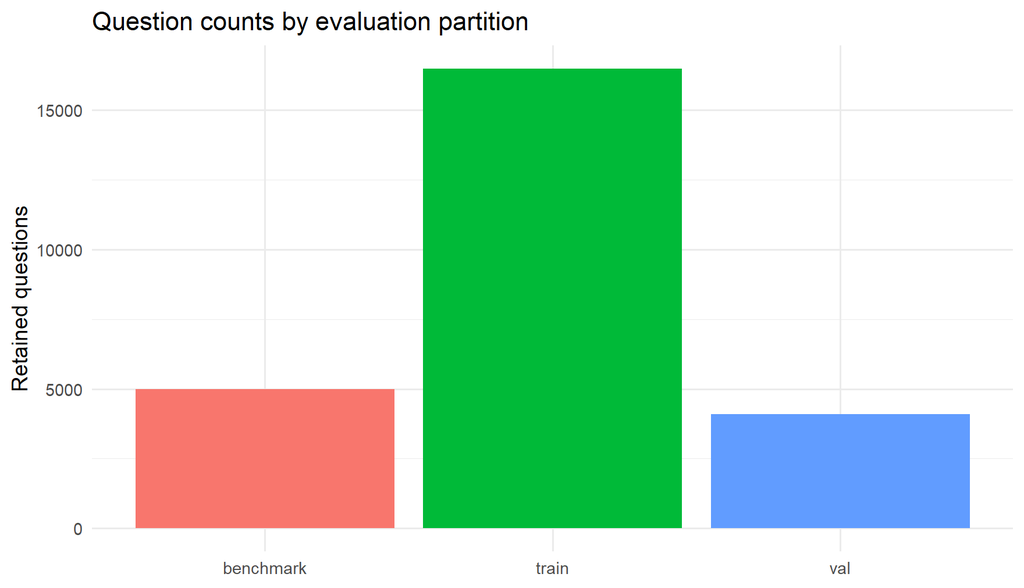

```r
persona_splits <- split(queries$split, queries$persona_id)
stopifnot(all(vapply(persona_splits, function(x) length(unique(x)) == 1L, logical(1))))
ggplot(partition, aes(split, questions, fill = split)) +
  geom_col(show.legend = FALSE) + labs(x = NULL, y = "Retained questions",
                                      title = "Question counts by evaluation partition")
```

# 3 Query and persona distributions

The plots below describe the retained sample. Query length is a character count, not a tokenizer count. Different persona histories can create different numbers of candidate memories, so aggregate row counts should not replace per-query retrieval evaluation.

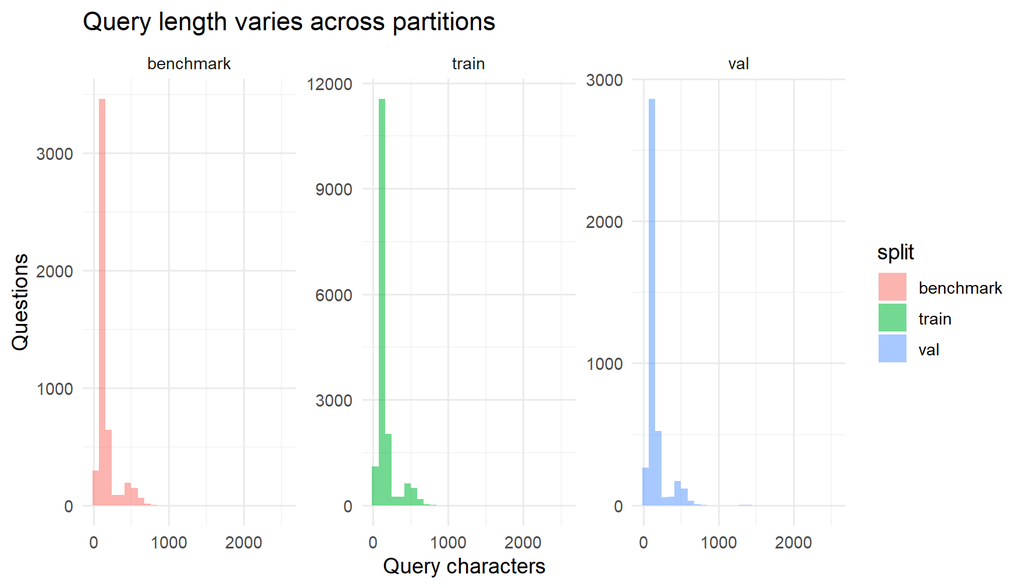

```r
queries$query_characters <- nchar(queries$query, type = "chars")
ggplot(queries, aes(query_characters, fill = split)) +
  geom_histogram(bins = 30, alpha = 0.55, position = "identity") +
  facet_wrap(~ split, scales = "free_y") + labs(x = "Query characters", y = "Questions",
                                               title = "Query length varies across partitions")
```

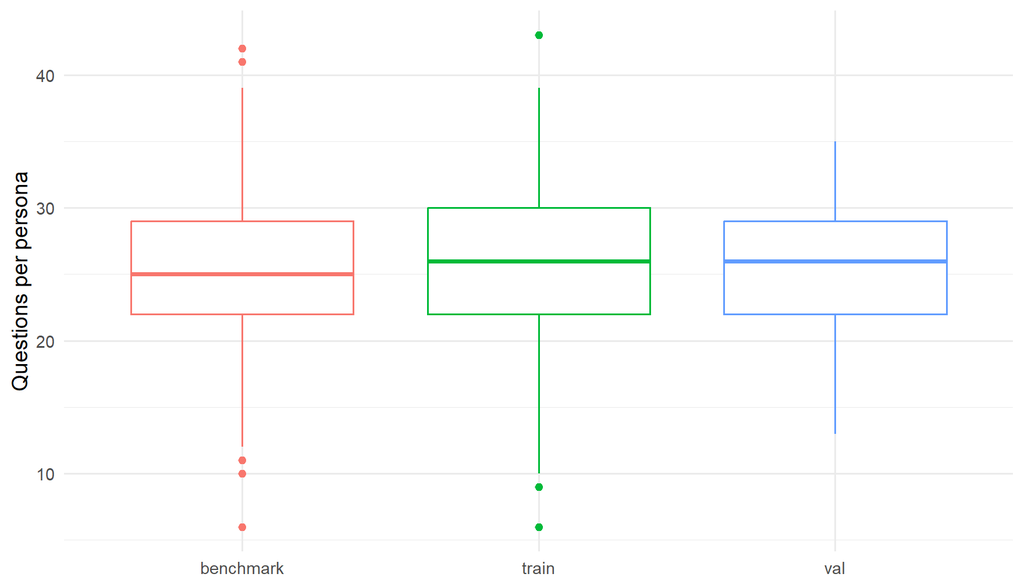

```r
persona_counts <- aggregate(query_id ~ persona_id + split, queries, length)
ggplot(persona_counts, aes(split, query_id, color = split)) +
  geom_boxplot(show.legend = FALSE) + labs(x = NULL, y = "Questions per persona")
```

```r
topic_counts <- sort(table(queries$topic_query), decreasing = TRUE)
topic <- data.frame(topic = names(topic_counts), questions = as.integer(topic_counts))
show_table(head(topic, 15), caption = "Most frequent supplied topic labels")
```

Most frequent supplied topic labels

| topic | questions |
| --- | --- |
| Travel | 2857 |
| Health | 2347 |
| Food | 2006 |
| Entertainment | 1443 |
| Work | 979 |
| travel | 892 |
| Home | 640 |
| Mental Health | 598 |
| health | 528 |
| Relationships | 467 |
| technology | 433 |
| food | 429 |
| Sports | 411 |
| entertainment | 408 |
| Fashion | 398 |

# 4 Alignment and update annotations

The `updated` field is a dataset annotation. It does not establish a wall-clock timestamp or the age of a real user preference. The `position` feature measures relative order within a history; it is a recency proxy. A later message can be relevant to an update, but later order alone does not prove that an earlier fact was corrected. The no-position ablation checks how much the model depends on this proxy.

Alignment status by partition; zero-count combinations are shown

| Var1 | Var2 | Freq |
| --- | --- | --- |
| benchmark | aligned | 4471 |
| train | aligned | 14822 |
| val | aligned | 3659 |
| benchmark | ambiguous_duplicate_sequence | 1 |
| train | ambiguous_duplicate_sequence | 0 |
| val | ambiguous_duplicate_sequence | 3 |
| benchmark | missing_exact_sequence | 527 |
| train | missing_exact_sequence | 1670 |
| val | missing_exact_sequence | 431 |

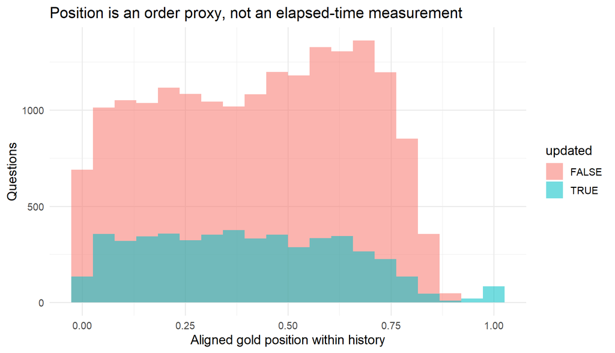

```r
if (!is.null(alignment)) {
  show_table(as.data.frame(table(alignment$split, alignment$status)),
        caption = "Alignment status by partition; zero-count combinations are shown")
  if ("gold_relative_position" %in% names(alignment)) {
    alignment$gold_relative_position <- suppressWarnings(as.numeric(alignment$gold_relative_position))
    present <- alignment[is.finite(alignment$gold_relative_position), , drop = FALSE]
    if (nrow(present)) print(ggplot(present, aes(gold_relative_position, fill = updated)) +
      geom_histogram(bins = 20, position = "identity", alpha = 0.55) +
      labs(x = "Aligned gold position within history", y = "Questions",
           title = "Position is an order proxy, not an elapsed-time measurement"))
  }
} else {
  alignment_json <- file.path(root, "reports/alignment.json")
  if (file.exists(alignment_json)) print(fromJSON(alignment_json)) else
    cat("Alignment report is not available yet. Run alignment before interpreting coverage.\n")
}
```

```r
show_table(as.data.frame(table(queries$split, queries$updated)),
      caption = "Supplied update annotation by partition")
```

Supplied update annotation by partition

| Var1 | Var2 | Freq |
| --- | --- | --- |
| benchmark | FALSE | 3952 |
| train | FALSE | 13308 |
| val | FALSE | 3244 |
| benchmark | TRUE | 1047 |
| train | TRUE | 3184 |
| val | TRUE | 849 |

# 5 Feature distributions and training design

Conversation size is measured in memory turns after excluding complete-profile system messages. The aligned evidence position above and the distribution below use source order only. Token lengths of candidate turns appear in `log_length`.

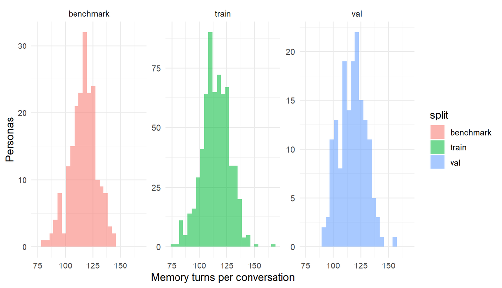

```r
if (!is.null(alignment)) {
  history_sizes <- unique(alignment[c("persona_id", "split", "memory_count")])
  history_sizes$memory_count <- as.numeric(history_sizes$memory_count)
  print(ggplot(history_sizes, aes(memory_count, fill = split)) +
    geom_histogram(bins = 25, position = "identity", alpha = 0.55) +
    facet_wrap(~ split, scales = "free_y") +
    labs(x = "Memory turns per conversation", y = "Personas"))
}
```

The logistic model uses exactly BM25 score, semantic similarity, lexical overlap, log memory length, and relative history position. The no-position model removes the last feature. A 300-tree probability forest uses the same five features with seed 310, `mtry = 2`, `min.node.size = 10`, and two threads. RRF is a retrieval baseline and is excluded from the learned model inputs.

Logistic features are centered and scaled using training rows only. Each cross-validation fold estimates its own centers and scales from the remaining personas. A constant or linearly redundant feature receives a zero coefficient and is recorded in `training_report.json`. Validation predictions come from models fitted to the complete training partition. Benchmark features are scored later using frozen models; the training program does not read benchmark files.

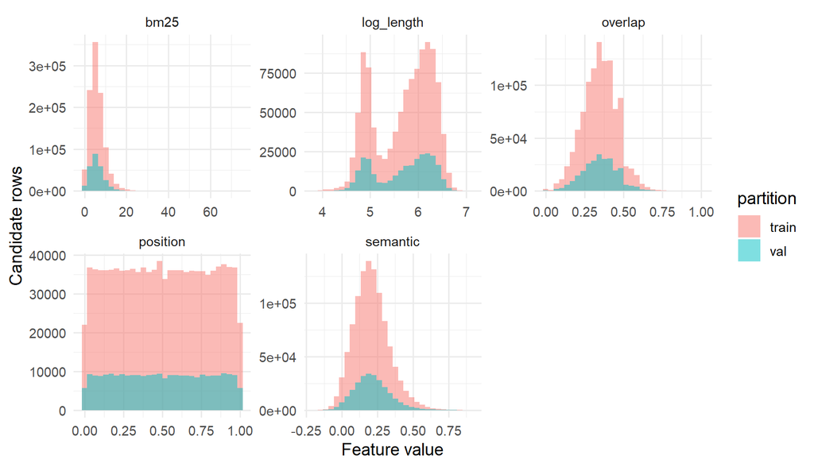

Observed candidate labels: zero means unannotated, not verified irrelevant

| Var1 | Var2 | Freq |
| --- | --- | --- |
| train | 0 | 1038255 |
| val | 0 | 257608 |
| train | 1 | 19468 |
| val | 1 | 4791 |

Training-only feature correlations

|  | bm25 | semantic | overlap | log_length | position |
| --- | --- | --- | --- | --- | --- |
| bm25 | 1.000 | 0.234 | 0.541 | 0.052 | -0.013 |
| semantic | 0.234 | 1.000 | 0.031 | -0.155 | -0.091 |
| overlap | 0.541 | 0.031 | 1.000 | 0.456 | 0.129 |
| log_length | 0.052 | -0.155 | 0.456 | 1.000 | 0.327 |
| position | -0.013 | -0.091 | 0.129 | 0.327 | 1.000 |

```r
features <- c("bm25", "semantic", "overlap", "log_length", "position")
if (!is.null(train) && !is.null(val)) {
  train$partition <- "train"
  val$partition <- "val"
  feature_data <- rbind(train, val)
  long <- do.call(rbind, lapply(features, function(name) data.frame(
    feature = name, value = as.numeric(feature_data[[name]]),
    partition = feature_data$partition, label = feature_data$label)))
  print(ggplot(long, aes(value, fill = partition)) +
    geom_histogram(bins = 30, position = "identity", alpha = 0.5) +
    facet_wrap(~ feature, scales = "free") + labs(x = "Feature value", y = "Candidate rows"))
  show_table(as.data.frame(table(feature_data$partition, feature_data$label)),
        caption = "Observed candidate labels: zero means unannotated, not verified irrelevant")
  show_table(round(cor(data.frame(lapply(train[features], as.numeric))), 3),
        caption = "Training-only feature correlations")
} else {
  cat("Training/validation feature tables are not available yet.\n")
}
```

# 6 Retrieval outcomes

Only verified computed rows from `reports/cv_query_metrics.csv`, `reports/val_query_metrics.csv` and `reports/benchmark_query_metrics.csv` appear below. Compare methods on the same query set and token budget. Candidate recall limits the best possible reranking result. Report candidate-pool coverage alongside ranking quality, and interpret results for updated questions separately when enough examples exist. Grouped out-of-fold predictions support development comparisons without scoring a persona using a model trained on its own candidates.

First computed per-query metric rows

| query_id | persona_id | split | updated | method | recall_at_5 | mrr_at_10 | budget_recall | candidate_recall | context_tokens | candidate_count |
| --- | --- | --- | --- | --- | --- | --- | --- | --- | --- | --- |
| train-00010 | 171 | val | FALSE | bm25 | 0.0 | 0.0 | 0.0 | 1.0 | 1967 | 63 |
| train-00010 | 171 | val | FALSE | semantic | 0.0 | 0.0 | 0.0 | 1.0 | 1999 | 63 |
| train-00010 | 171 | val | FALSE | rrf | 0.0 | 0.0 | 0.0 | 1.0 | 1955 | 63 |
| train-00010 | 171 | val | FALSE | logistic | 0.0 | 0.0 | 0.0 | 1.0 | 1953 | 63 |
| train-00010 | 171 | val | FALSE | logistic_no_position | 0.0 | 0.0 | 0.0 | 1.0 | 1960 | 63 |
| train-00010 | 171 | val | FALSE | random_forest | 0.0 | 0.0 | 0.0 | 1.0 | 1955 | 63 |
| train-00012 | 194 | val | TRUE | bm25 | 0.5 | 0.2 | 0.5 | 1.0 | 1991 | 83 |
| train-00012 | 194 | val | TRUE | semantic | 0.0 | 0.0 | 0.0 | 1.0 | 1957 | 83 |
| train-00012 | 194 | val | TRUE | rrf | 0.5 | 0.2 | 0.5 | 1.0 | 1973 | 83 |
| train-00012 | 194 | val | TRUE | logistic | 0.0 | 0.0 | 0.5 | 1.0 | 1990 | 83 |
| train-00012 | 194 | val | TRUE | logistic_no_position | 0.0 | 0.0 | 0.5 | 1.0 | 1983 | 83 |
| train-00012 | 194 | val | TRUE | random_forest | 0.0 | 0.0 | 0.0 | 1.0 | 1934 | 83 |
| train-00020 | 987 | val | FALSE | bm25 | 0.0 | 0.0 | 0.0 | 1.0 | 1953 | 70 |
| train-00020 | 987 | val | FALSE | semantic | 0.0 | 0.0 | 0.0 | 1.0 | 1967 | 70 |
| train-00020 | 987 | val | FALSE | rrf | 0.0 | 0.0 | 0.0 | 1.0 | 1981 | 70 |
| train-00020 | 987 | val | FALSE | logistic | 0.0 | 0.0 | 0.0 | 1.0 | 1997 | 70 |
| train-00020 | 987 | val | FALSE | logistic_no_position | 0.0 | 0.0 | 0.0 | 1.0 | 1905 | 70 |
| train-00020 | 987 | val | FALSE | random_forest | 0.0 | 0.0 | 0.0 | 1.0 | 1984 | 70 |
| train-00028 | 496 | val | TRUE | bm25 | 0.0 | 0.125 | 0.0 | 1.0 | 1988 | 74 |
| train-00028 | 496 | val | TRUE | semantic | 1.0 | 1.0 | 1.0 | 1.0 | 1974 | 74 |

Unweighted means over reported queries

| split | method | recall_at_5 | mrr_at_10 | budget_recall | candidate_recall | context_tokens | candidate_count |
| --- | --- | --- | --- | --- | --- | --- | --- |
| cv | bm25 | 0.2575 | 0.2381 | 0.2889 | 0.8650 | 1965.243 | 71.3617 |
| val | bm25 | 0.2662 | 0.2403 | 0.2953 | 0.8576 | 1964.520 | 71.7133 |
| cv | logistic | 0.3578 | 0.3039 | 0.3930 | 0.8650 | 1964.126 | 71.3617 |
| val | logistic | 0.3586 | 0.3103 | 0.3970 | 0.8576 | 1963.808 | 71.7133 |
| cv | logistic_no_position | 0.3518 | 0.2993 | 0.3857 | 0.8650 | 1963.718 | 71.3617 |
| val | logistic_no_position | 0.3544 | 0.3067 | 0.3911 | 0.8576 | 1964.120 | 71.7133 |
| cv | random_forest | 0.3475 | 0.3054 | 0.3891 | 0.8650 | 1964.826 | 71.3617 |
| val | random_forest | 0.3526 | 0.3069 | 0.3883 | 0.8576 | 1964.326 | 71.7133 |
| cv | rrf | 0.3215 | 0.2855 | 0.3552 | 0.8650 | 1964.877 | 71.3617 |
| val | rrf | 0.3247 | 0.2902 | 0.3585 | 0.8576 | 1964.785 | 71.7133 |
| cv | semantic | 0.3375 | 0.2888 | 0.3726 | 0.8650 | 1963.386 | 71.3617 |
| val | semantic | 0.3391 | 0.2950 | 0.3740 | 0.8576 | 1962.756 | 71.7133 |

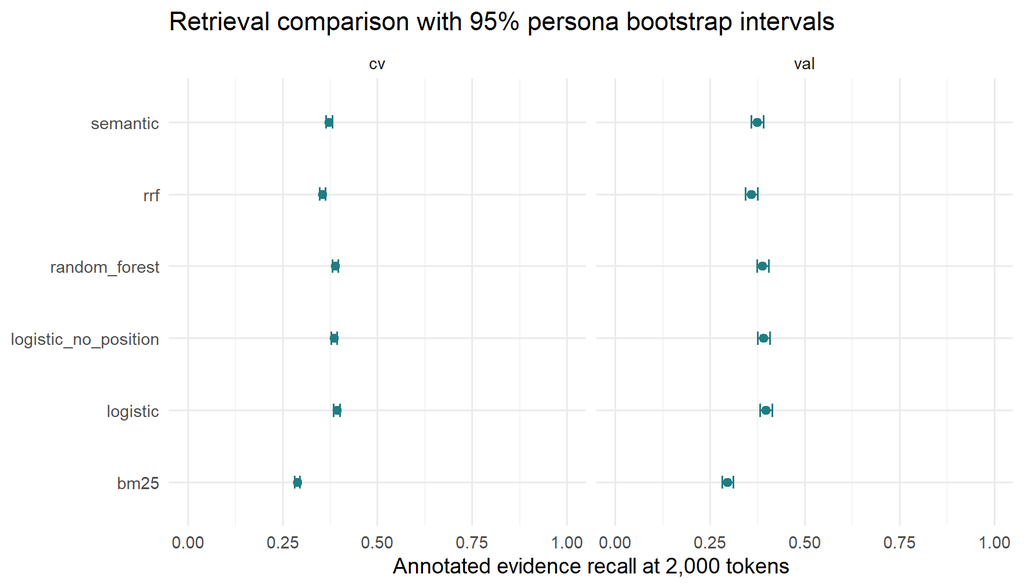

```r
if (!is.null(metrics) && nrow(metrics)) {
  show_table(head(metrics, 20), caption = "First computed per-query metric rows")
  numeric_names <- setdiff(names(metrics), c("query_id", "persona_id", "split", "method", "updated", "topic_query"))
  numeric_names <- numeric_names[vapply(metrics[numeric_names], function(x)
    all(is.finite(suppressWarnings(as.numeric(x)))), logical(1))]
  if ("method" %in% names(metrics) && length(numeric_names)) {
    values <- metrics
    values[numeric_names] <- lapply(values[numeric_names], as.numeric)
    groups <- intersect(c("split", "method"), names(values))
    summary <- aggregate(values[numeric_names], values[groups], mean)
    show_table(summary, digits = 4, caption = "Unweighted means over reported queries")
  }
  summaries <- lapply(c("cv", "val", "benchmark"), function(s) {
    table <- read_optional(paste0("reports/", s, "_summary.csv"))
    if (!is.null(table)) table$split <- s
    table
  })
  summaries <- Filter(Negate(is.null), summaries)
  if (length(summaries)) {
    intervals <- do.call(rbind, summaries)
    intervals <- intervals[intervals$metric == "budget_recall", , drop = FALSE]
    for (name in c("mean", "ci_low", "ci_high")) intervals[[name]] <- pmr_finite_number(intervals[[name]], name)
    print(ggplot(intervals, aes(method, mean)) +
      geom_errorbar(aes(ymin = ci_low, ymax = ci_high), width = 0.18, color = "#207D83") +
      geom_point(color = "#207D83", size = 2) + coord_flip() + facet_wrap(~ split) +
      scale_y_continuous(limits = c(0, 1)) +
      labs(x = NULL, y = "Annotated evidence recall at 2,000 tokens",
           title = "Retrieval comparison with 95% persona bootstrap intervals"))
  }
} else {
  cat("No computed retrieval metrics are present. This notebook makes no performance claim.\n")
}
```

# 7 Reproducibility and limits

Run `Rscript R/bootstrap.R` first, then the documented download, cleaning, alignment, feature, training, and evaluation commands. `Rscript R/render.R --output reports/eda.html` renders this notebook from the current artifacts. Keep development samples and final benchmark results identified in their manifests. Hyperparameters and token budgets should be selected using training/validation evidence before one final benchmark evaluation.

This is an annotated-memory retrieval study. It does not establish causal effects, personalization quality for real users, or performance on arbitrary conversations. Synthetic prompts, incomplete labels, exact-alignment exclusions, and query correlations within personas limit interpretation. Bootstrap intervals should resample personas when reporting uncertainty over this clustered dataset.